# New HIV diagnoses in the UK by probable route of exposure: a paradigm shift

Student: 210155372

27/4/2022

**Background**

On the 5th of June 1981, in its weekly epidemiological digest, Morbidity and Mortality Weekly Report, the American Centres for Disease Control and Prevention reported unusual clusters of Pneumocystis pneumonia (PCP) in five homosexual men. This event represents the origin of the AIDS epidemic. Acquired immunodeficiency syndrome (AIDS) is a chronic medical condition caused by HIV, the human immunodeficiency virus. HIV infects and kills the CD4 T lymphocytes of the immune system, leaving the body vulnerable to cancers and life-threatening infections. To slow the rapid growth in cases of this deadly virus, since the beginning various medical agencies started to study the epidemiological spread of HIV.

**Motivation and research questions**

In the ninth edition of the “Robbins and Cotran Pathologic Basis of Disease (2014)”, an extremely popular medical textbook, the authors indicate that in 2009 the majority of infected people in the United States were men who had sex with men. Considering that the epidemiological situation of HIV in the UK is not particularly different from the US, and considering that the statistics reported in the textbook are outdated, I saw the opportunity to ask the following research questions:

1. Is still “sex between men” the main exposure category for HIV in the UK?
2. If the HIV cases attributed to the “heterosexual contact” outnumber the ones related to “sex between men”, which is the gender with the most significant incidence?

**Data Origins**

For this project, I used the “Country and region HIV data tables” from the UK Health Security Agency that can be found on the site gov.uk. The data tables’ information that was used for the project is the number of cases per year, from 2011 to 2020, for new HIV diagnoses in the UK by probable route of exposure. The link is:

https://assets.publishing.service.gov.uk/government/uploads/system/uploads/attachment_data/file/1037993/hiv-country-region-data-tables-2021.ods

**Libraries**

In this section, I imported all the libraries I used in the code.

```r
#Importing all the libraries used in the code
library(tidyverse)
library(here)
library(gganimate)
library(gifski)
library(wesanderson)
library(magick)
```

**Data Preparation**

In this section, I organised the data set to ease its access and analysis.

```r
#Loading the data set
raw_data <- read.csv(here("Data", "hiv_country_region_data_tables_2021.csv"),
                     #Choosing the specific rows
                     skip = 32, nrows = 20, sep = ";")

#Eliminating unused columns
raw_data <- raw_data[ , -c(1:8,19:28)]

#Eliminating unused rows
raw_data <- raw_data[-c(6,7,9:16,18,19) , ]

#Transposing the data set
plot_data <- t(raw_data)

#Summing three columns together in a new column
new_col <- plot_data[,6] + plot_data[,7] + plot_data[,8]

#Adding the new column to the data set
plot_data <- cbind(plot_data, new_col)

#Naming columns
colnames(plot_data) <- c("Year",
                         "Sex_Between_Men",
                         "Heterosexual_Contact_Men",
                         "Heterosexual_Contact_Women",
                         "Heterosexual_Contact_Total",
                         "Injecting_Drug_Use",
                         "Vertical_Transmission",
                         "Other",
                         "Other_Exposure_Categories")

#Eliminating the name of the rows
rownames(plot_data) <- NULL

#Converting the matrix into a data frame
plot_data <- as.data.frame.matrix(plot_data)
```

**Data Visualisation**

I created an animated GIF with two line graphs in this section.

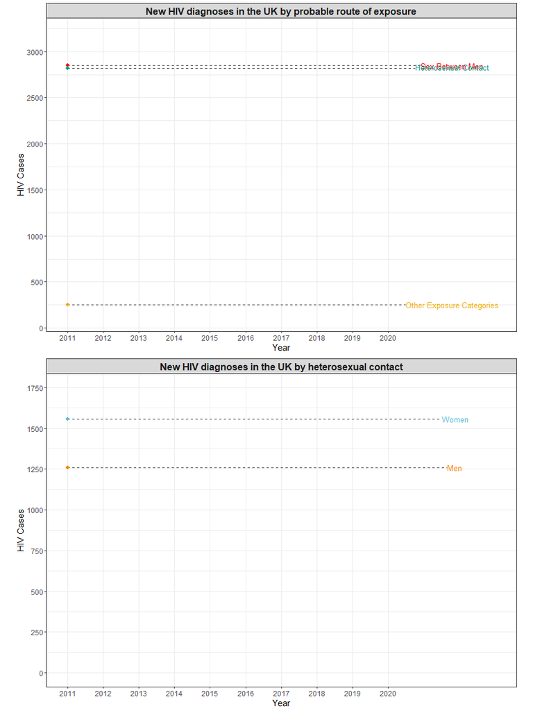

```r
#Giving the title to the first graph
plot_data$title1 <- "New HIV diagnoses in the UK by probable route of exposure"

#Giving the title to the second graph
plot_data$title2 <- "New HIV diagnoses in the UK by heterosexual contact"

#Choosing the palette for the colours of the graph
pal <- wes_palette("Darjeeling1", n = 5)


#Plotting first graph
HIV_plot1 <- ggplot() +
  #Plotting lines
  geom_line(data = plot_data,aes(x = Year, y = Sex_Between_Men, group = 1),
            colour = pal[1], size=1) +
  geom_line(data = plot_data, aes(x =Year, y = Heterosexual_Contact_Total,
                                  group = 1),
            colour = pal[2], size=1) +
  geom_line(data = plot_data, aes(x =Year, y = Other_Exposure_Categories,
                                  group = 1),
            colour = pal[3], size=1) +
  #Plotting dashed segments
  geom_segment(data = plot_data,aes(x=Year, y= Sex_Between_Men,
                                    xend = 2020.9,  yend = Sex_Between_Men,
                                    group = 1),
               linetype = 2, colour = 'gray28', show.legend = FALSE) +
  geom_segment(data = plot_data,aes(x=Year, y= Heterosexual_Contact_Total,
                                    xend = 2020.75,
                                    yend = Heterosexual_Contact_Total,
                                    group = 1),
               linetype = 2, colour = 'gray28', show.legend = FALSE) +
  geom_segment(data = plot_data,aes(x=Year, y= Other_Exposure_Categories,
                                    xend = 2020.5,
                                    yend = Other_Exposure_Categories,group = 1),
               linetype = 2, colour = 'gray28', show.legend = FALSE) +
  #Plotting texts
  geom_text(data = plot_data, aes(x = 2020.9, y= Sex_Between_Men,
                                 label = "Sex Between Men", size=15,
                                 group = 1),
            color = pal[1], hjust=0, vjust = 0.5, show.legend = FALSE) +
  geom_text(data = plot_data,aes(x = 2020.75, y= Heterosexual_Contact_Total,
                                 label = "Heterosexual Contact", size= 15,
                                 group = 1),
            color = pal[2], hjust=0,  vjust = 0.25, show.legend = FALSE) +
  geom_text(data = plot_data,aes(x = 2020.5, y= Other_Exposure_Categories,
                                 label = "Other Exposure Categories",
                                 size=15, group = 1),
            color = pal[3], hjust = 0, show.legend = FALSE) +
  #Choosing names, ticks and limits of the axes
  scale_x_continuous(name="Year", limits = c(2011,2023),
                     breaks = round(seq(2011,2020, by=1)),
                     minor_breaks = round(seq(2011,2020, by=1))) +
  scale_y_continuous(name = "HIV Cases", breaks = round(seq(0,3000, by=500))) +
  #Displaying the title inside a grey box
  facet_grid(. ~ title1) +
  #Choosing the theme for the plot
  theme_bw() +
  #Adjusting the aspect ratio of the graph and the text font
  theme(aspect.ratio=1/1.5, text = element_text(size=15),
        strip.text.x = element_text(size = 16, hjust = 0.5, face= "bold"))


#Plotting second graph
HIV_plot2 <- ggplot() +
  #Plotting lines
  geom_line(data = plot_data,aes(x = Year, y = Heterosexual_Contact_Men,
                                 group = 1),
            colour = pal[4], size=1) +
  geom_line(data = plot_data, aes(x =Year, y = Heterosexual_Contact_Women,
                                  group = 1),
            colour = pal[5], size=1) +
  #Plotting dashed segments
  geom_segment(data = plot_data,aes(x=Year, y= Heterosexual_Contact_Men,
                                    xend = 2021.65,
                                    yend = Heterosexual_Contact_Men,group = 1),
               linetype = 2, colour = 'gray28', show.legend = FALSE) +
  geom_segment(data = plot_data,aes(x=Year, y= Heterosexual_Contact_Women,
                                    xend = 2021.5,
                                    yend = Heterosexual_Contact_Women,
                                    group = 1),
               linetype = 2, colour = 'gray28', show.legend = FALSE) +
  #Plotting texts
  geom_text(data = plot_data,aes(x = 2021.65, y= Heterosexual_Contact_Men,
                                 label = "Men",size=15, group = 1),
            color = pal[4], hjust = 0, show.legend = FALSE) +
  geom_text(data = plot_data,aes(x = 2021.5, y= Heterosexual_Contact_Women,
                                 label = "Women", size=15,group = 1),
            color = pal[5], hjust = 0, show.legend = FALSE) +
  #Choosing names, ticks and limits of the axes
  scale_x_continuous(name="Year", breaks = round(seq(2011,2020,by=1)),
                     minor_breaks = round(seq(2011,2020, by=1)),
                     limits = c(2011,2023)) +
  scale_y_continuous(name = "HIV Cases",
                     breaks = round(seq(0,1750, by=250)),
                     limits = c(0,1750)) +
  #Displaying the title inside a grey box
  facet_grid(. ~ title2) +
  #Choosing the theme for the plot
  theme_bw() +
  #Adjusting the aspect ratio of the graph and the text font
  theme(text=element_text(size=15), aspect.ratio=1/1.5,
        strip.text.x = element_text(size = 16, hjust = 0.5, face= "bold"))


#Creating the first animation
HIV_animation1 <- HIV_plot1 +
  #Adding the points to the animation
  geom_point(data =plot_data,aes(x=Year, y = Sex_Between_Men,
                                 group = seq_along(Year)),
             pch=16, size=2.5,colour = pal[1]) +
  geom_point(data = plot_data, aes(x =Year,
                                   y = Heterosexual_Contact_Total,
                                   group = seq_along(Year)),
             pch=16, size=2.5,colour = pal[2]) +
  geom_point(data = plot_data, aes(x =Year, y = Other_Exposure_Categories,
                                   group = seq_along(Year)),
             pch=16, size =2.5,colour = pal[3]) +
  #Specifying each frame by subsequent years
  transition_reveal(Year)
#Rendering the animation
HIV_animation1 <- animate(HIV_animation1, renderer = gifski_renderer(),
                          end_pause = 50, height = 600, width = 900)


#Creating the second animation
HIV_animation2 <- HIV_plot2 +
  #Adding the points to the animation
  geom_point(data =plot_data,aes(x=Year, y = Heterosexual_Contact_Men,
                                 group = seq_along(Year)),
             pch=16, size=2.5,colour = pal[4]) +
  geom_point(data = plot_data, aes(x =Year, y = Heterosexual_Contact_Women,
                                   group = seq_along(Year)),
             pch=16, size=2.5,colour = pal[5]) +
  #Specifying each frame by subsequent years
  transition_reveal(Year)
#Rendering the animation
HIV_animation2 <-animate(HIV_animation2, renderer = gifski_renderer(),
                         end_pause = 50, height = 600, width = 900)


#Loading the set of images as a GIF
HIV_gif1 <- image_read(HIV_animation1)
HIV_gif2 <- image_read(HIV_animation2)


#Merging the GIFs together

#Creating the first frame of the new GIF
HIV_gif3 <- image_append(c(HIV_gif1[1], HIV_gif2[1]),TRUE)

#Starting a loop
for(i in 2:50){
  #Adding all the other frames to the GIF
  combined <- image_append(c(HIV_gif1[i], HIV_gif2[i]), TRUE)
  HIV_gif3 <- c(HIV_gif3, combined)
  }


#Saving the GIFs
anim_save(here("Plots", "HIV_route_of_exposure.gif"), HIV_gif1)
anim_save(here("Plots", "HIV_heterosexual_contact.gif"), HIV_gif2)
anim_save(here("Plots", "HIV_final.gif"), HIV_gif3)


#Displaying the final animated GIF
HIV_gif3
```

**Results**

In the first graph, “New HIV diagnoses in the UK by probable route of exposure”, we can see a reduction in the number of new cases, which is remarkably consistent for the category “sex between men”. This drastic decrease has been achieved in all probability with the introduction of the HIV prevention pill PrEP (pre-exposure prophylaxis) in the UK, which has reduced the cases since 2014 predominantly in gay and bisexual men. Another element to notice is that in 2020, the cases related to the “heterosexual contact” route of exposure outnumbered the case for the “sex between men” category. For this year (2020), the ulterior reduction of cases results from the Covid 19 lockdown that contributed to the reduction in testing. But considering that in sexual health clinics, there was a 33% fall in HIV testing by heterosexuals compared to the lower 7% rate of gay men, the higher number of cases in heterosexuals if compared to the number of cases in gay men is even more significant. The second graph, “New HIV diagnoses in the UK by heterosexual contact”, clarifies that there is a more significant incidence of HIV cases in heterosexual women than in heterosexual men.

**Future Directions**

For a future project, it would be interesting to compare, using a data visualization strategy, the British epidemiological situation of HIV with countries that have a different sociocultural status in order to investigate possible relevant variations in the current epidemiological spread of HIV.

**References**

- Centers for Disease Control (CDC). Pneumocystis pneumonia–Los Angeles. MMWR Morb Mortal Wkly Rep. 1981 Jun 5;30(21):250-2. PMID: 6265753.
- Kumar, V., Abbas, A. K., Fausto, N., & Aster, J. C. (2014). Robbins and Cotran pathologic basis of disease, professional edition e-book. Elsevier health sciences.
- The Guardian (2022) HIV now infects more heterosexual people than gay or bisexual men – we need a new strategy, 9 Febraury.